# 评估类 subagent 数量与软件开发质量

Bensz Conan

2026-08-01

```r
# 目的：加载完整 episode 数据和预先计算的描述性统计
# 输入：tmp/quality_analysis 下的两个 RDS 文件
# 参数：analysis_mode 固定为 descriptive_pilot
# 输出：processed_data、computation_results 与正文内联统计量
if (!file.exists("00.Environment.R")) stop("Missing 00.Environment.R in analysis directory.")
source("00.Environment.R")
source("quality_analysis_functions.R")
data_dir <- file.path("tmp", "quality_analysis")
if (!dir.exists(data_dir)) stop("请先运行 quality_analysis.R 生成分析数据。")
processed_data <- readRDS(file.path(data_dir, "processed_data.rds"))
computation_results <- readRDS(file.path(data_dir, "computation_results.rds"))
source(file.path("templates", "nature_colors.R"))
source(file.path("templates", "nature_theme.R"))
source(file.path("templates", "datatables_helper.R"))
options(stringsAsFactors = FALSE)
```

## 1 数据概览

下面的表格以 episode 为一行，保留 intention-to-treat 的计划 evaluator 数、实际完成数、oracle 质量分、运行成本和协议状态。没有把 subagent 或测试用例扩张为统计样本。

```r
# 目的：展示未经阈值筛选的三条 episode 记录
# 输入：processed_data
# 参数：pageLength=3，完整呈现 pilot
# 输出：可交互 episode 表
render_dt_output(processed_data, n = nrow(processed_data), scrollX = TRUE, pageLength = 3)
```

|  | run_id | episode_id | ordinal | order_position | evaluator_count | episode_status | quality_score | oracle_code_score | scorer_status | scorer_error | delivery_completed | wall_seconds | input_tokens | output_tokens | total_tokens | changed_file_count | git_commit | workspace_manifest_sha256 | scored_content_sha256 | sealed_entry_count | scored_entry_count | omitted_sealed_entry_count | requested_evaluators | completed_evaluators | summary_count | executor_count | protocol_ok | protocol_deviations | score_api_quality | … |
| --- | --- | --- | --- | --- | --- | --- | --- | --- | --- | --- | --- | --- | --- | --- | --- | --- | --- | --- | --- | --- | --- | --- | --- | --- | --- | --- | --- | --- | --- | --- |
| 1 | run-856b289d45e9356b5377 | episode-3e9fa6349481cbf99505 | 3 | 3 | 9 | timed_out | 0 | 100 | ok |  | False | 1800.022 |  |  |  | 72 | 1a9fc49a761d6f36abf514175f1fb45ba475164f | 6f3cf16393e6cc1dd1d895de0523416fb32cb5bddc11cfc4451bbbf8df95df06 | 8ee22bee3c0f22bd633c3fa1576d5ea7f4f2d73f35ab672265ef4e3d9ee7d71a | 76 | 75 | 1 | 9 | 9 | 0 | 1 | False | missing manifest | 10 | … |
| 2 | run-856b289d45e9356b5377 | episode-d6f10eebe2297845a3ad | 1 | 1 | 3 | completed | 100 | 100 | ok |  | True | 1660.663 | 2480939 | 22327 | 2503266 | 38 | c77eb0825094a483d5bdbebeecc6e485a980bbf6 | 19ae6641c0ddea3f87642766ae4ffb056508d3cf4f43eef159fb157d7e5b56c9 | 24345b4195f4166ea996456b79b7aa1bebc7dbb12fc5de9fc7ae5a4b94c185d3 | 42 | 41 | 1 | 3 | 3 | 1 | 1 | True | [{'stage': 'evaluator-1 startup', 'description': 'The first host spawn request failed before a thread was created because fork_turns=all referenced an unavailable host thread. The same evaluator numbe… | 10 | … |
| 3 | run-856b289d45e9356b5377 | episode-fe435ec6e06d27a53183 | 2 | 2 | 6 | completed | 100 | 100 | ok |  | True | 1769.974 | 1876149 | 19303 | 1895452 | 56 | cdc4a773ec3cddcfcbe5a755017a405365916349 | d81a128c76f819cec517014d4aff9b1ef02a527a8c0d9320046ce285fa2f9c31 | ef7bde74162f052ffa65e35303e1d80fd9bbb21513074fe8151ea63145f504e8 | 60 | 59 | 1 | 6 | 5 | 1 | 1 | False | [{'evaluator': 1, 'stage': 'spawn', 'error': 'no thread with id', 'replacement_launched': False}] | 10 | … |

当前数据结果显示，本次 pilot 共包含 3 个 episode，每个计划条件各 1 次；端到端质量分位于 0.0–100.0 分之间，而超时瞬间保存的代码 oracle 分位于 100.0–100.0 分之间。实际运行位置按 evaluator 数为 3 → 6 → 9，形成固定升序。**这三条记录只能描述当前 fixture 与当前时间窗中的个案差异**，不能把单次随机 rollout 当作稳定组均值，也不能把最后一组超时归因于 evaluator 数；后续若重复实验，应继续以 episode 为唯一统计单位、轮换顺序并保留失败记录。

## 2 关键函数、参数与源代码位置

| 分析过程/产物 | 关键函数/对象 | 关键参数 | 设置理由 | 源代码位置 |
| --- | --- | --- | --- | --- |
| 盲化 oracle 评分 | `export_final_snapshot()` / `oracle_score()` | 六类预注册权重，总分满分 | 从 sealed final commit 导出并核对临时快照，评分先于 treatment 读取 | scripts/score_run.py:113 |
| episode 数据整理 | `utils::read.csv()` / `saveRDS()` | 每个 evaluator count 恰有一行 | pilot 的三个条件各运行一次，缺失或重复立即失败 | analysis/quality_analysis.R:12 |
| 描述性趋势 | `stats::lm()` / `stats::cor()` | `quality_score ~ evaluator_count` / Spearman | 仅量化三个观测的方向，不进行显著性推断 | analysis/quality_analysis.R:31 |
| 质量与成本作图 | `.q01_quality_plot()` / `.q01_cost_plot()` | x breaks 对应全部条件；质量轴覆盖满分范围 | 展示原始点，避免用平滑线或误导性误差条夸大单次/组 | analysis/quality_analysis_functions.R:19 |

## 3 软件质量

质量图展示三个经交付门禁调整的原始分数：episode 只有端到端 completed 才保留 oracle code score，超时或失败按交付门禁归零。图形同时保存矢量 PDF 与用于视觉复核的 JPG，纵轴固定覆盖完整满分范围，避免视觉上夸大小差异。

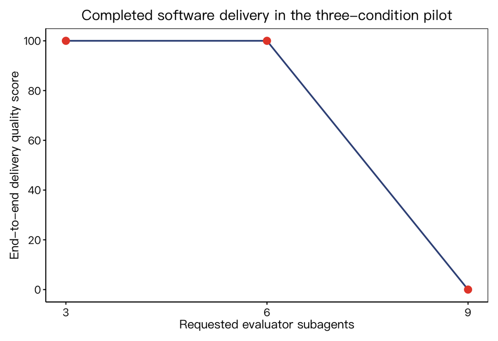

```r
# 目的：比较 3/6/9 evaluator 条件的端到端交付质量分
# 输入：processed_data
# 参数：7×4.8 英寸、11 pt 基准字体、0–100 固定纵轴
# 输出：quality-score.pdf、JPG 预览与 HTML 内图形
quality_plot <- .q01_quality_plot(processed_data)
figure_dir <- file.path("tmp", "quality_analysis", "figures")
preview_dir <- params$plot_run_dir
dir.create(figure_dir, recursive = TRUE, showWarnings = FALSE)
dir.create(preview_dir, recursive = TRUE, showWarnings = FALSE)
ggplot2::ggsave(file.path(figure_dir, "quality-score.pdf"), quality_plot, width = 7, height = 4.8, device = grDevices::cairo_pdf)
ggplot2::ggsave(file.path(preview_dir, "quality-score.jpg"), quality_plot, width = 7, height = 4.8, dpi = params$plot_preview_dpi)
quality_plot
```

结果解读：当前数据的最强信号是最高端到端质量分出现在 3 个 evaluator 条件，为 100.0 分；最高 evaluator 条件的交付分低于已完成条件，三个点的描述性线性斜率为每增加一个 evaluator -16.67 分，Spearman 方向系数为 -0.87。三组 sealed final commit 的代码 oracle 分范围仅为 100.0–100.0，表明**功能正确性出现天花板；本次固定升序 rollout 中没有观察到更多 evaluator 对应的额外正确性收益，且最后一组未完成交付**。当前只有 3 个 episode，无法估计 CI 或 bootstrap 稳定性，且该差异与运行顺序完全混杂；可证伪的下一步是在冻结 Prompt、fixture 与 scorer 后轮换顺序、每臂至少重复 3 次，并检查该方向是否在时间区组内重复出现。

## 4 质量构成

各需求类别的分数用于定位质量差异来自基础 TTL、LRU、single-flight、取消/失败还是 invalidation race；类别权重在运行前固定，未根据结果调整。

```r
# 目的：展示每个 episode 的预注册类别得分
# 输入：processed_data 中 score_ 前缀列
# 参数：只选择 treatment、总分和类别分
# 输出：可交互类别得分表
category_columns <- grep("^score_", names(processed_data), value = TRUE)
category_table <- processed_data[c("evaluator_count", "quality_score", "oracle_code_score", category_columns)]
render_dt_output(category_table, n = nrow(category_table), scrollX = TRUE, pageLength = 3)
```

|  | evaluator_count | quality_score | oracle_code_score | score_api_quality | score_basic_ttl | score_failure_cancel | score_invalidation_race | score_lru_capacity | score_single_flight | score_per_minute | score_per_1000_tokens |
| --- | --- | --- | --- | --- | --- | --- | --- | --- | --- | --- | --- |
| 1 | 9 | 0 | 100 | 10 | 15 | 20 | 20 | 15 | 20 | 0 |  |
| 2 | 3 | 100 | 100 | 10 | 15 | 20 | 20 | 15 | 20 | 3.613014801919475 | 0.03994781217817044 |
| 3 | 6 | 100 | 100 | 10 | 15 | 20 | 20 | 15 | 20 | 3.389880303326489 | 0.05275786461487814 |

当前数据结果显示，三组代码 artifact 在预注册的 TTL、LRU、single-flight、取消与 invalidation race 类别上总分均达到 100.0，其中 invalidation race 已覆盖失效后的新请求世代，但端到端交付分最低为 0.0。**代码正确不等于实验工作流按时完成**：9-evaluator 条件的正确代码在超时捕获时仍缺少完成的总结与终态协议；下一轮应保持同一类别权重，并同时把 completed 状态与类别得分作为不可替代的两个判据。

## 5 执行成本

运行时间包含 evaluator、总结、顶层实现和公开测试，是增加评估 agent 所附带成本的直接观察量。

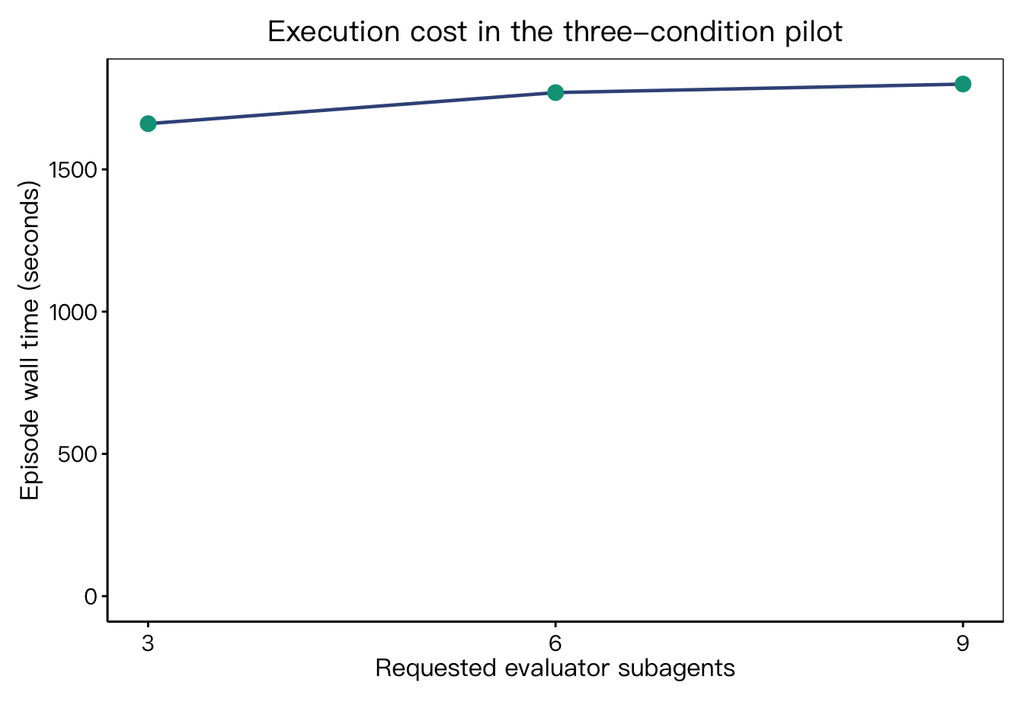

```r
# 目的：比较三种 evaluator 数量的 episode 墙钟时间
# 输入：processed_data
# 参数：7×4.8 英寸、11 pt 基准字体
# 输出：wall-time.pdf、JPG 预览与 HTML 内图形
cost_plot <- .q01_cost_plot(processed_data)
ggplot2::ggsave(file.path(figure_dir, "wall-time.pdf"), cost_plot, width = 7, height = 4.8, device = grDevices::cairo_pdf)
ggplot2::ggsave(file.path(preview_dir, "wall-time.jpg"), cost_plot, width = 7, height = 4.8, dpi = params$plot_preview_dpi)
cost_plot
```

结果解读：当前数据结果显示，最长 episode 是 9 个 evaluator 条件，耗时 1800.0 秒；最短耗时为 1660.7 秒，最长/最短时间比为 1.08。最高 evaluator 条件比最低条件多完成 6 份评估结果，却少获得 100.0 分端到端质量；这一反向差异是需要复验的观察信号，**不能在固定升序、单次/组设计中解释为数量效应**。若要分离纯数量效应，需要轮换执行顺序并另做固定总 evaluator token 预算的实验，以质量分/千 token 和质量分/分钟作为共同判据。

## 6 讨论与分析

### 6.1 主要发现

当前数据的最强信号是较低两个 evaluator 条件的端到端交付分均为 100.0，最高条件因超时为 0.0。当前数据同时显示，三组代码 oracle 分均为 100.0，功能分没有随 evaluator 数增加。当前数据的描述性斜率为 -16.67 分/evaluator，协议操纵通过的 episode 为 1/3；**本次固定升序 rollout 没有显示更多 evaluator 对应的代码正确性收益，并观察到最后一个 9-evaluator episode 未按时交付，但两者不能建立因果联系**。当前仅有 3 个 episode，无法估计 CI 或 bootstrap 稳定性；requested count 与运行位置都须保留，不能删去超时条件。

### 6.2 局限性

每臂只有 1 次、只有一个 AsyncTTLCache fixture、所有 subagent 来自同一模型家族，结论同时受 rollout 随机性、时间漂移、API 限流、总结上下文负担和共享外部 Codex 配置影响。原 pilot 固定按 3 → 6 → 9 运行，数量与顺序完全混杂；各条件还携带不同计算成本，因此当前斜率不是纯数量因果效应。隐藏测试虽在 episode workspace 外并采用预注册权重，仍只覆盖一个具体并发缓存契约，不能代表一般软件工程质量。

### 6.3 可落地后续

冻结本轮 Prompt、fixture、Codex build、parallel-vibe 公共 digest 与 scorer 后，使用预注册随机顺序并按时间区组轮换位置，把每臂扩展到至少 3 次；输入仍为同一 baseline，判据是原始 episode 分数、区组内方向一致性和宽区间效应估计，而不是把测试项当样本计算小 p 值。若成本允许，再增加 2 个难度相近但缺陷结构不同的 fixture，以任务为 block 检查数量效应能否跨任务复现。

## 7 数字准确性验证

| 数字描述 | 来源变量/计算 | 报告位置 |
| --- | --- | --- |
| episode 数和每臂样本量 | `nrow(processed_data)` / `table(evaluator_count)` | 数据概览 |
| 最高、最低交付分与代码分 | `quality_score` / `oracle_code_score` | 软件质量与质量构成 |
| 描述性斜率与 Spearman 系数 | `stats::lm()` / `stats::cor(method="spearman")` | 软件质量 |
| 最长与最短运行时间 | `which.max(wall_seconds)` / `min(wall_seconds)` | 执行成本 |
| 协议通过数 | `sum(protocol_ok)` | 讨论与分析 |

验证结论：正文关键数字均由当前 `processed_data` 或 `computation_results` 通过内联 R 动态嵌入；oracle 评分发生在 treatment 读取之前，评分对象由 sealed final commit 导出并与 sealed workspace manifest 逐文件核对，评分前后均验证 RawBundle seal；报告没有把 subagent、测试用例或发现条目当作独立统计样本。